# Optimal Treatment Analysis

## Outcome Variable

**Outcome Variable:** ever_wasted

## Predictor Variables

**Intervention Variable:** perdiar6

**Adjustment Set:**

- arm
- sex
- W_mage
- meducyrs
- W_mhtcm
- W_mwtkg
- W_mbmi
- W_birthwt
- W_birthlen
- W_nrooms
- month
- brthmon
- impfloor
- impsan
- safeh20
- delta_W_mage
- delta_meducyrs
- delta_W_mhtcm
- delta_W_mwtkg
- delta_W_mbmi
- delta_W_birthwt
- delta_W_birthlen
- delta_W_nrooms
- delta_month
- delta_brthmon
- delta_impfloor
- delta_impsan
- delta_safeh20

## Stratifying Variables

The analysis was stratified on these variable(s):

- agecat
- studyid
- country

## Data Summary

| agecat | studyid | country | perdiar6 | ever_wasted | n_cell | n |
| --- | --- | --- | --- | --- | --- | --- |
| 0-24 months (no birth wast) | ki0047075b-MAL-ED | BANGLADESH | (0%, 5%] | 0 | 75 | 261 |
| 0-24 months (no birth wast) | ki0047075b-MAL-ED | BANGLADESH | (0%, 5%] | 1 | 23 | 261 |
| 0-24 months (no birth wast) | ki0047075b-MAL-ED | BANGLADESH | 0% | 0 | 63 | 261 |
| 0-24 months (no birth wast) | ki0047075b-MAL-ED | BANGLADESH | 0% | 1 | 20 | 261 |
| 0-24 months (no birth wast) | ki0047075b-MAL-ED | BANGLADESH | >5% | 0 | 65 | 261 |
| 0-24 months (no birth wast) | ki0047075b-MAL-ED | BANGLADESH | >5% | 1 | 15 | 261 |
| 0-24 months (no birth wast) | ki0047075b-MAL-ED | BRAZIL | (0%, 5%] | 0 | 14 | 229 |
| 0-24 months (no birth wast) | ki0047075b-MAL-ED | BRAZIL | (0%, 5%] | 1 | 1 | 229 |
| 0-24 months (no birth wast) | ki0047075b-MAL-ED | BRAZIL | 0% | 0 | 202 | 229 |
| 0-24 months (no birth wast) | ki0047075b-MAL-ED | BRAZIL | 0% | 1 | 10 | 229 |
| 0-24 months (no birth wast) | ki0047075b-MAL-ED | BRAZIL | >5% | 0 | 1 | 229 |
| 0-24 months (no birth wast) | ki0047075b-MAL-ED | BRAZIL | >5% | 1 | 1 | 229 |
| 0-24 months (no birth wast) | ki0047075b-MAL-ED | INDIA | (0%, 5%] | 0 | 86 | 242 |
| 0-24 months (no birth wast) | ki0047075b-MAL-ED | INDIA | (0%, 5%] | 1 | 42 | 242 |
| 0-24 months (no birth wast) | ki0047075b-MAL-ED | INDIA | 0% | 0 | 32 | 242 |
| 0-24 months (no birth wast) | ki0047075b-MAL-ED | INDIA | 0% | 1 | 23 | 242 |
| 0-24 months (no birth wast) | ki0047075b-MAL-ED | INDIA | >5% | 0 | 35 | 242 |
| 0-24 months (no birth wast) | ki0047075b-MAL-ED | INDIA | >5% | 1 | 24 | 242 |
| 0-24 months (no birth wast) | ki0047075b-MAL-ED | NEPAL | (0%, 5%] | 0 | 63 | 238 |
| 0-24 months (no birth wast) | ki0047075b-MAL-ED | NEPAL | (0%, 5%] | 1 | 13 | 238 |
| 0-24 months (no birth wast) | ki0047075b-MAL-ED | NEPAL | 0% | 0 | 64 | 238 |
| 0-24 months (no birth wast) | ki0047075b-MAL-ED | NEPAL | 0% | 1 | 18 | 238 |
| 0-24 months (no birth wast) | ki0047075b-MAL-ED | NEPAL | >5% | 0 | 66 | 238 |
| 0-24 months (no birth wast) | ki0047075b-MAL-ED | NEPAL | >5% | 1 | 14 | 238 |
| 0-24 months (no birth wast) | ki0047075b-MAL-ED | PERU | (0%, 5%] | 0 | 88 | 299 |
| 0-24 months (no birth wast) | ki0047075b-MAL-ED | PERU | (0%, 5%] | 1 | 5 | 299 |
| 0-24 months (no birth wast) | ki0047075b-MAL-ED | PERU | 0% | 0 | 80 | 299 |
| 0-24 months (no birth wast) | ki0047075b-MAL-ED | PERU | 0% | 1 | 6 | 299 |
| 0-24 months (no birth wast) | ki0047075b-MAL-ED | PERU | >5% | 0 | 111 | 299 |
| 0-24 months (no birth wast) | ki0047075b-MAL-ED | PERU | >5% | 1 | 9 | 299 |

[output cut: 258 more lines]

The following strata were considered:

- agecat: 0-24 months (no birth wast), studyid: ki0047075b-MAL-ED, country: BANGLADESH
- agecat: 0-24 months (no birth wast), studyid: ki0047075b-MAL-ED, country: BRAZIL
- agecat: 0-24 months (no birth wast), studyid: ki0047075b-MAL-ED, country: INDIA
- agecat: 0-24 months (no birth wast), studyid: ki0047075b-MAL-ED, country: NEPAL
- agecat: 0-24 months (no birth wast), studyid: ki0047075b-MAL-ED, country: PERU
- agecat: 0-24 months (no birth wast), studyid: ki0047075b-MAL-ED, country: SOUTH AFRICA
- agecat: 0-24 months (no birth wast), studyid: ki0047075b-MAL-ED, country: TANZANIA, UNITED REPUBLIC OF
- agecat: 0-24 months (no birth wast), studyid: ki1000109-ResPak, country: PAKISTAN
- agecat: 0-24 months (no birth wast), studyid: ki1017093-NIH-Birth, country: BANGLADESH
- agecat: 0-24 months (no birth wast), studyid: ki1017093b-PROVIDE, country: BANGLADESH
- agecat: 0-24 months (no birth wast), studyid: ki1017093c-NIH-Crypto, country: BANGLADESH
- agecat: 0-24 months (no birth wast), studyid: ki1114097-CMIN, country: BANGLADESH
- agecat: 0-24 months (no birth wast), studyid: ki1114097-CMIN, country: BRAZIL
- agecat: 0-24 months (no birth wast), studyid: ki1114097-CMIN, country: GUINEA-BISSAU
- agecat: 0-24 months (no birth wast), studyid: ki1114097-CMIN, country: PERU
- agecat: 0-24 months (no birth wast), studyid: ki1114097-CONTENT, country: PERU
- agecat: 0-6 months (no birth wast), studyid: ki0047075b-MAL-ED, country: BANGLADESH
- agecat: 0-6 months (no birth wast), studyid: ki0047075b-MAL-ED, country: BRAZIL
- agecat: 0-6 months (no birth wast), studyid: ki0047075b-MAL-ED, country: INDIA
- agecat: 0-6 months (no birth wast), studyid: ki0047075b-MAL-ED, country: NEPAL
- agecat: 0-6 months (no birth wast), studyid: ki0047075b-MAL-ED, country: PERU
- agecat: 0-6 months (no birth wast), studyid: ki0047075b-MAL-ED, country: SOUTH AFRICA
- agecat: 0-6 months (no birth wast), studyid: ki0047075b-MAL-ED, country: TANZANIA, UNITED REPUBLIC OF
- agecat: 0-6 months (no birth wast), studyid: ki1000109-ResPak, country: PAKISTAN
- agecat: 0-6 months (no birth wast), studyid: ki1017093-NIH-Birth, country: BANGLADESH
- agecat: 0-6 months (no birth wast), studyid: ki1017093b-PROVIDE, country: BANGLADESH
- agecat: 0-6 months (no birth wast), studyid: ki1017093c-NIH-Crypto, country: BANGLADESH
- agecat: 0-6 months (no birth wast), studyid: ki1114097-CMIN, country: BANGLADESH
- agecat: 0-6 months (no birth wast), studyid: ki1114097-CMIN, country: BRAZIL
- agecat: 0-6 months (no birth wast), studyid: ki1114097-CMIN, country: GUINEA-BISSAU
- agecat: 0-6 months (no birth wast), studyid: ki1114097-CMIN, country: PERU
- agecat: 0-6 months (no birth wast), studyid: ki1114097-CONTENT, country: PERU
- agecat: 6-24 months, studyid: ki0047075b-MAL-ED, country: BANGLADESH
- agecat: 6-24 months, studyid: ki0047075b-MAL-ED, country: BRAZIL
- agecat: 6-24 months, studyid: ki0047075b-MAL-ED, country: INDIA
- agecat: 6-24 months, studyid: ki0047075b-MAL-ED, country: NEPAL
- agecat: 6-24 months, studyid: ki0047075b-MAL-ED, country: PERU
- agecat: 6-24 months, studyid: ki0047075b-MAL-ED, country: SOUTH AFRICA
- agecat: 6-24 months, studyid: ki0047075b-MAL-ED, country: TANZANIA, UNITED REPUBLIC OF
- agecat: 6-24 months, studyid: ki1000109-ResPak, country: PAKISTAN
- agecat: 6-24 months, studyid: ki1017093-NIH-Birth, country: BANGLADESH
- agecat: 6-24 months, studyid: ki1017093b-PROVIDE, country: BANGLADESH
- agecat: 6-24 months, studyid: ki1017093c-NIH-Crypto, country: BANGLADESH
- agecat: 6-24 months, studyid: ki1114097-CMIN, country: BANGLADESH
- agecat: 6-24 months, studyid: ki1114097-CMIN, country: BRAZIL
- agecat: 6-24 months, studyid: ki1114097-CMIN, country: GUINEA-BISSAU
- agecat: 6-24 months, studyid: ki1114097-CMIN, country: PERU
- agecat: 6-24 months, studyid: ki1114097-CONTENT, country: PERU

### Dropped Strata

Some strata were dropped due to rare outcomes:

- agecat: 0-24 months (no birth wast), studyid: ki0047075b-MAL-ED, country: BRAZIL
- agecat: 0-24 months (no birth wast), studyid: ki0047075b-MAL-ED, country: SOUTH AFRICA
- agecat: 0-24 months (no birth wast), studyid: ki0047075b-MAL-ED, country: TANZANIA, UNITED REPUBLIC OF
- agecat: 0-24 months (no birth wast), studyid: ki1114097-CMIN, country: BRAZIL
- agecat: 0-24 months (no birth wast), studyid: ki1114097-CONTENT, country: PERU
- agecat: 0-6 months (no birth wast), studyid: ki0047075b-MAL-ED, country: BRAZIL
- agecat: 0-6 months (no birth wast), studyid: ki0047075b-MAL-ED, country: NEPAL
- agecat: 0-6 months (no birth wast), studyid: ki0047075b-MAL-ED, country: PERU
- agecat: 0-6 months (no birth wast), studyid: ki0047075b-MAL-ED, country: SOUTH AFRICA
- agecat: 0-6 months (no birth wast), studyid: ki0047075b-MAL-ED, country: TANZANIA, UNITED REPUBLIC OF
- agecat: 0-6 months (no birth wast), studyid: ki1114097-CMIN, country: BRAZIL
- agecat: 0-6 months (no birth wast), studyid: ki1114097-CMIN, country: GUINEA-BISSAU
- agecat: 0-6 months (no birth wast), studyid: ki1114097-CMIN, country: PERU
- agecat: 0-6 months (no birth wast), studyid: ki1114097-CONTENT, country: PERU
- agecat: 6-24 months, studyid: ki0047075b-MAL-ED, country: BRAZIL
- agecat: 6-24 months, studyid: ki0047075b-MAL-ED, country: PERU
- agecat: 6-24 months, studyid: ki0047075b-MAL-ED, country: SOUTH AFRICA
- agecat: 6-24 months, studyid: ki0047075b-MAL-ED, country: TANZANIA, UNITED REPUBLIC OF
- agecat: 6-24 months, studyid: ki1114097-CMIN, country: BRAZIL
- agecat: 6-24 months, studyid: ki1114097-CONTENT, country: PERU

## Methods Detail

We’re interested in the causal parameters $E[Y_a]$ for all values of $a \in \mathcal{A}$. These parameters represent the mean outcome if, possibly contrary to fact, we intervened to set all units to have $A=a$. Under the randomization and positivity assumptions, these are identified by the statistical parameters $\psi_a=E_W[E_{Y|A,W}(Y|A=a,W)]$. In addition, we’re interested in the mean of $Y$, $E[Y]$ under no intervention (the observed mean). We will estimate these parameters by using SuperLearner to fit the relevant likelihood factors – $E_{Y|A,W}(Y|A=a,W)$ and $p(A=a|W)$, and then updating our likelihood fit using a joint TMLE.

For unadjusted analyses ($W=\{\}$), initial likelihoods were estimated using Lrnr_glm to estimate the simple $E(Y|A)$ and Lrnr_mean to estimate $p(A)$. For adjusted analyses, a small library containing Lrnr_glmnet, Lrnr_xgboost, and Lrnr_mean was used.

Having estimated these parameters, we will then use the delta method to estimate relative risks and attributable risks relative to a prespecified baseline level of $A$.

# Results Detail

## Results Plots

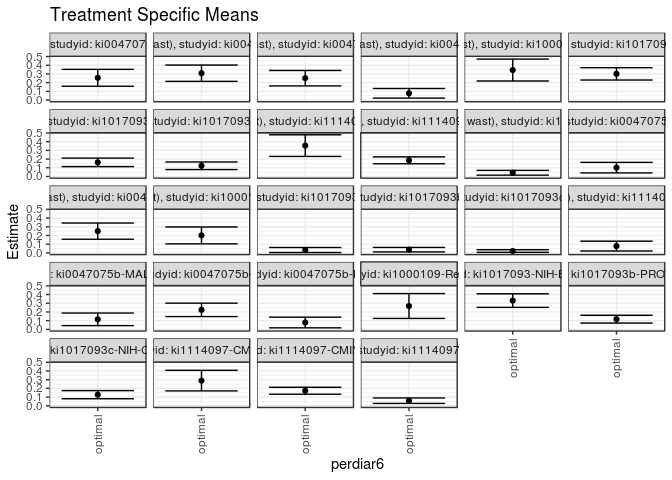

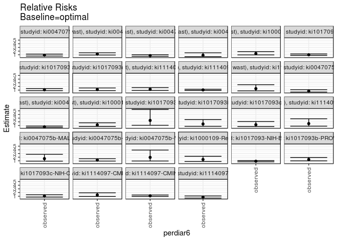

## Results Table

### Parameter: TSM

| agecat | studyid | country | intervention_level | baseline_level | estimate | ci_lower | ci_upper |
| --- | --- | --- | --- | --- | --- | --- | --- |
| 0-24 months (no birth wast) | ki0047075b-MAL-ED | BANGLADESH | optimal | NA | 0.2558358 | 0.1589698 | 0.3527018 |
| 0-24 months (no birth wast) | ki0047075b-MAL-ED | INDIA | optimal | NA | 0.3083008 | 0.2146426 | 0.4019590 |
| 0-24 months (no birth wast) | ki0047075b-MAL-ED | NEPAL | optimal | NA | 0.2513026 | 0.1627442 | 0.3398609 |
| 0-24 months (no birth wast) | ki0047075b-MAL-ED | PERU | optimal | NA | 0.0778751 | 0.0227750 | 0.1329752 |
| 0-24 months (no birth wast) | ki1000109-ResPak | PAKISTAN | optimal | NA | 0.3446822 | 0.2189964 | 0.4703679 |
| 0-24 months (no birth wast) | ki1017093-NIH-Birth | BANGLADESH | optimal | NA | 0.3007144 | 0.2297953 | 0.3716336 |
| 0-24 months (no birth wast) | ki1017093b-PROVIDE | BANGLADESH | optimal | NA | 0.1624060 | 0.1135211 | 0.2112908 |
| 0-24 months (no birth wast) | ki1017093c-NIH-Crypto | BANGLADESH | optimal | NA | 0.1232536 | 0.0795732 | 0.1669340 |
| 0-24 months (no birth wast) | ki1114097-CMIN | BANGLADESH | optimal | NA | 0.3547508 | 0.2305631 | 0.4789386 |
| 0-24 months (no birth wast) | ki1114097-CMIN | GUINEA-BISSAU | optimal | NA | 0.1857901 | 0.1460489 | 0.2255314 |
| 0-24 months (no birth wast) | ki1114097-CMIN | PERU | optimal | NA | 0.0428541 | 0.0154143 | 0.0702939 |
| 0-6 months (no birth wast) | ki0047075b-MAL-ED | BANGLADESH | optimal | NA | 0.1017399 | 0.0412577 | 0.1622221 |
| 0-6 months (no birth wast) | ki0047075b-MAL-ED | INDIA | optimal | NA | 0.2504861 | 0.1574226 | 0.3435495 |
| 0-6 months (no birth wast) | ki1000109-ResPak | PAKISTAN | optimal | NA | 0.2012047 | 0.1046746 | 0.2977348 |
| 0-6 months (no birth wast) | ki1017093-NIH-Birth | BANGLADESH | optimal | NA | 0.0334195 | 0.0044435 | 0.0623955 |
| 0-6 months (no birth wast) | ki1017093b-PROVIDE | BANGLADESH | optimal | NA | 0.0372322 | 0.0115954 | 0.0628690 |
| 0-6 months (no birth wast) | ki1017093c-NIH-Crypto | BANGLADESH | optimal | NA | 0.0220257 | 0.0068542 | 0.0371973 |
| 0-6 months (no birth wast) | ki1114097-CMIN | BANGLADESH | optimal | NA | 0.0784351 | 0.0220964 | 0.1347738 |
| 6-24 months | ki0047075b-MAL-ED | BANGLADESH | optimal | NA | 0.1150933 | 0.0428211 | 0.1873656 |
| 6-24 months | ki0047075b-MAL-ED | INDIA | optimal | NA | 0.2238577 | 0.1470516 | 0.3006637 |
| 6-24 months | ki0047075b-MAL-ED | NEPAL | optimal | NA | 0.0787444 | 0.0172493 | 0.1402394 |
| 6-24 months | ki1000109-ResPak | PAKISTAN | optimal | NA | 0.2681843 | 0.1254267 | 0.4109420 |
| 6-24 months | ki1017093-NIH-Birth | BANGLADESH | optimal | NA | 0.3305187 | 0.2526132 | 0.4084241 |
| 6-24 months | ki1017093b-PROVIDE | BANGLADESH | optimal | NA | 0.1169887 | 0.0722048 | 0.1617726 |
| 6-24 months | ki1017093c-NIH-Crypto | BANGLADESH | optimal | NA | 0.1278442 | 0.0811289 | 0.1745595 |
| 6-24 months | ki1114097-CMIN | BANGLADESH | optimal | NA | 0.2891445 | 0.1709632 | 0.4073258 |
| 6-24 months | ki1114097-CMIN | GUINEA-BISSAU | optimal | NA | 0.1728552 | 0.1329857 | 0.2127246 |
| 6-24 months | ki1114097-CMIN | PERU | optimal | NA | 0.0584487 | 0.0272681 | 0.0896294 |

### Parameter: E(Y)

| agecat | studyid | country | intervention_level | baseline_level | estimate | ci_lower | ci_upper |
| --- | --- | --- | --- | --- | --- | --- | --- |
| 0-24 months (no birth wast) | ki0047075b-MAL-ED | BANGLADESH | observed | NA | 0.2222222 | 0.1716883 | 0.2727561 |
| 0-24 months (no birth wast) | ki0047075b-MAL-ED | INDIA | observed | NA | 0.3677686 | 0.3068900 | 0.4286472 |
| 0-24 months (no birth wast) | ki0047075b-MAL-ED | NEPAL | observed | NA | 0.1890756 | 0.1392237 | 0.2389275 |
| 0-24 months (no birth wast) | ki0047075b-MAL-ED | PERU | observed | NA | 0.0668896 | 0.0385244 | 0.0952548 |
| 0-24 months (no birth wast) | ki1000109-ResPak | PAKISTAN | observed | NA | 0.4578755 | 0.3986666 | 0.5170843 |
| 0-24 months (no birth wast) | ki1017093-NIH-Birth | BANGLADESH | observed | NA | 0.2981575 | 0.2614320 | 0.3348829 |
| 0-24 months (no birth wast) | ki1017093b-PROVIDE | BANGLADESH | observed | NA | 0.1775837 | 0.1489858 | 0.2061816 |
| 0-24 months (no birth wast) | ki1017093c-NIH-Crypto | BANGLADESH | observed | NA | 0.1432361 | 0.1182149 | 0.1682572 |
| 0-24 months (no birth wast) | ki1114097-CMIN | BANGLADESH | observed | NA | 0.4372624 | 0.3771974 | 0.4973274 |
| 0-24 months (no birth wast) | ki1114097-CMIN | GUINEA-BISSAU | observed | NA | 0.1951754 | 0.1694388 | 0.2209121 |
| 0-24 months (no birth wast) | ki1114097-CMIN | PERU | observed | NA | 0.0600559 | 0.0426409 | 0.0774709 |
| 0-6 months (no birth wast) | ki0047075b-MAL-ED | BANGLADESH | observed | NA | 0.0730769 | 0.0413805 | 0.1047733 |
| 0-6 months (no birth wast) | ki0047075b-MAL-ED | INDIA | observed | NA | 0.1576763 | 0.1115695 | 0.2037832 |
| 0-6 months (no birth wast) | ki1000109-ResPak | PAKISTAN | observed | NA | 0.2287823 | 0.1786790 | 0.2788855 |
| 0-6 months (no birth wast) | ki1017093-NIH-Birth | BANGLADESH | observed | NA | 0.0794473 | 0.0574004 | 0.1014943 |
| 0-6 months (no birth wast) | ki1017093b-PROVIDE | BANGLADESH | observed | NA | 0.0527086 | 0.0359384 | 0.0694789 |
| 0-6 months (no birth wast) | ki1017093c-NIH-Crypto | BANGLADESH | observed | NA | 0.0267023 | 0.0151493 | 0.0382553 |
| 0-6 months (no birth wast) | ki1114097-CMIN | BANGLADESH | observed | NA | 0.1183206 | 0.0791362 | 0.1575050 |
| 6-24 months | ki0047075b-MAL-ED | BANGLADESH | observed | NA | 0.1833333 | 0.1342773 | 0.2323893 |
| 6-24 months | ki0047075b-MAL-ED | INDIA | observed | NA | 0.2723404 | 0.2153029 | 0.3293779 |
| 6-24 months | ki0047075b-MAL-ED | NEPAL | observed | NA | 0.1531915 | 0.1070438 | 0.1993392 |
| 6-24 months | ki1000109-ResPak | PAKISTAN | observed | NA | 0.3652174 | 0.3028556 | 0.4275792 |
| 6-24 months | ki1017093-NIH-Birth | BANGLADESH | observed | NA | 0.2939002 | 0.2554778 | 0.3323226 |
| 6-24 months | ki1017093b-PROVIDE | BANGLADESH | observed | NA | 0.1609756 | 0.1319065 | 0.1900447 |
| 6-24 months | ki1017093c-NIH-Crypto | BANGLADESH | observed | NA | 0.1315068 | 0.1069744 | 0.1560393 |
| 6-24 months | ki1114097-CMIN | BANGLADESH | observed | NA | 0.3849206 | 0.3247254 | 0.4451159 |
| 6-24 months | ki1114097-CMIN | GUINEA-BISSAU | observed | NA | 0.1896745 | 0.1639180 | 0.2154311 |
| 6-24 months | ki1114097-CMIN | PERU | observed | NA | 0.0420420 | 0.0267891 | 0.0572949 |

### Parameter: RR

| agecat | studyid | country | intervention_level | baseline_level | estimate | ci_lower | ci_upper |
| --- | --- | --- | --- | --- | --- | --- | --- |
| 0-24 months (no birth wast) | ki0047075b-MAL-ED | BANGLADESH | observed | optimal | 0.8686126 | 0.6404080 | 1.1781362 |
| 0-24 months (no birth wast) | ki0047075b-MAL-ED | INDIA | observed | optimal | 1.1928890 | 0.9286135 | 1.5323749 |
| 0-24 months (no birth wast) | ki0047075b-MAL-ED | NEPAL | observed | optimal | 0.7523824 | 0.5620052 | 1.0072493 |
| 0-24 months (no birth wast) | ki0047075b-MAL-ED | PERU | observed | optimal | 0.8589348 | 0.4844755 | 1.5228201 |
| 0-24 months (no birth wast) | ki1000109-ResPak | PAKISTAN | observed | optimal | 1.3283990 | 0.9552549 | 1.8473017 |
| 0-24 months (no birth wast) | ki1017093-NIH-Birth | BANGLADESH | observed | optimal | 0.9914970 | 0.8102280 | 1.2133205 |
| 0-24 months (no birth wast) | ki1017093b-PROVIDE | BANGLADESH | observed | optimal | 1.0934554 | 0.8482416 | 1.4095567 |
| 0-24 months (no birth wast) | ki1017093c-NIH-Crypto | BANGLADESH | observed | optimal | 1.1621249 | 0.8556614 | 1.5783514 |
| 0-24 months (no birth wast) | ki1114097-CMIN | BANGLADESH | observed | optimal | 1.2325901 | 0.9035208 | 1.6815088 |
| 0-24 months (no birth wast) | ki1114097-CMIN | GUINEA-BISSAU | observed | optimal | 1.0505156 | 0.8877699 | 1.2430957 |
| 0-24 months (no birth wast) | ki1114097-CMIN | PERU | observed | optimal | 1.4014033 | 0.7939992 | 2.4734675 |
| 0-6 months (no birth wast) | ki0047075b-MAL-ED | BANGLADESH | observed | optimal | 0.7182719 | 0.4622219 | 1.1161620 |
| 0-6 months (no birth wast) | ki0047075b-MAL-ED | INDIA | observed | optimal | 0.6294815 | 0.4749904 | 0.8342209 |
| 0-6 months (no birth wast) | ki1000109-ResPak | PAKISTAN | observed | optimal | 1.1370623 | 0.7468883 | 1.7310631 |
| 0-6 months (no birth wast) | ki1017093-NIH-Birth | BANGLADESH | observed | optimal | 2.3772735 | 1.0507714 | 5.3783621 |
| 0-6 months (no birth wast) | ki1017093b-PROVIDE | BANGLADESH | observed | optimal | 1.4156749 | 0.7723216 | 2.5949493 |
| 0-6 months (no birth wast) | ki1017093c-NIH-Crypto | BANGLADESH | observed | optimal | 1.2123211 | 0.7115135 | 2.0656284 |
| 0-6 months (no birth wast) | ki1114097-CMIN | BANGLADESH | observed | optimal | 1.5085160 | 0.8048585 | 2.8273546 |
| 6-24 months | ki0047075b-MAL-ED | BANGLADESH | observed | optimal | 1.5929101 | 0.9143475 | 2.7750528 |
| 6-24 months | ki0047075b-MAL-ED | INDIA | observed | optimal | 1.2165785 | 0.9383185 | 1.5773572 |
| 6-24 months | ki0047075b-MAL-ED | NEPAL | observed | optimal | 1.9454277 | 0.9586965 | 3.9477445 |
| 6-24 months | ki1000109-ResPak | PAKISTAN | observed | optimal | 1.3618148 | 0.8312539 | 2.2310147 |
| 6-24 months | ki1017093-NIH-Birth | BANGLADESH | observed | optimal | 0.8892090 | 0.7292600 | 1.0842398 |
| 6-24 months | ki1017093b-PROVIDE | BANGLADESH | observed | optimal | 1.3759931 | 0.9903546 | 1.9117970 |
| 6-24 months | ki1017093c-NIH-Crypto | BANGLADESH | observed | optimal | 1.0286494 | 0.7557847 | 1.4000278 |
| 6-24 months | ki1114097-CMIN | BANGLADESH | observed | optimal | 1.3312396 | 0.9232743 | 1.9194719 |
| 6-24 months | ki1114097-CMIN | GUINEA-BISSAU | observed | optimal | 1.0973031 | 0.9142629 | 1.3169888 |
| 6-24 months | ki1114097-CMIN | PERU | observed | optimal | 0.7192978 | 0.4888983 | 1.0582759 |

### Parameter: PAR

| agecat | studyid | country | intervention_level | baseline_level | estimate | ci_lower | ci_upper |
| --- | --- | --- | --- | --- | --- | --- | --- |
| 0-24 months (no birth wast) | ki0047075b-MAL-ED | BANGLADESH | optimal | NA | -0.0336136 | -0.1118952 | 0.0446680 |
| 0-24 months (no birth wast) | ki0047075b-MAL-ED | INDIA | optimal | NA | 0.0594678 | -0.0181129 | 0.1370485 |
| 0-24 months (no birth wast) | ki0047075b-MAL-ED | NEPAL | optimal | NA | -0.0622269 | -0.1341157 | 0.0096618 |
| 0-24 months (no birth wast) | ki0047075b-MAL-ED | PERU | optimal | NA | -0.0109855 | -0.0557536 | 0.0337827 |
| 0-24 months (no birth wast) | ki1000109-ResPak | PAKISTAN | optimal | NA | 0.1131933 | -0.0001198 | 0.2265064 |
| 0-24 months (no birth wast) | ki1017093-NIH-Birth | BANGLADESH | optimal | NA | -0.0025570 | -0.0632701 | 0.0581561 |
| 0-24 months (no birth wast) | ki1017093b-PROVIDE | BANGLADESH | optimal | NA | 0.0151777 | -0.0261292 | 0.0564846 |
| 0-24 months (no birth wast) | ki1017093c-NIH-Crypto | BANGLADESH | optimal | NA | 0.0199825 | -0.0178660 | 0.0578309 |
| 0-24 months (no birth wast) | ki1114097-CMIN | BANGLADESH | optimal | NA | 0.0825115 | -0.0272876 | 0.1923106 |
| 0-24 months (no birth wast) | ki1114097-CMIN | GUINEA-BISSAU | optimal | NA | 0.0093853 | -0.0219111 | 0.0406817 |
| 0-24 months (no birth wast) | ki1114097-CMIN | PERU | optimal | NA | 0.0172018 | -0.0076051 | 0.0420087 |
| 0-6 months (no birth wast) | ki0047075b-MAL-ED | BANGLADESH | optimal | NA | -0.0286630 | -0.0742829 | 0.0169569 |
| 0-6 months (no birth wast) | ki0047075b-MAL-ED | INDIA | optimal | NA | -0.0928097 | -0.1641518 | -0.0214676 |
| 0-6 months (no birth wast) | ki1000109-ResPak | PAKISTAN | optimal | NA | 0.0275776 | -0.0570193 | 0.1121744 |
| 0-6 months (no birth wast) | ki1017093-NIH-Birth | BANGLADESH | optimal | NA | 0.0460278 | 0.0161112 | 0.0759444 |
| 0-6 months (no birth wast) | ki1017093b-PROVIDE | BANGLADESH | optimal | NA | 0.0154765 | -0.0075446 | 0.0384975 |
| 0-6 months (no birth wast) | ki1017093c-NIH-Crypto | BANGLADESH | optimal | NA | 0.0046765 | -0.0072198 | 0.0165729 |
| 0-6 months (no birth wast) | ki1114097-CMIN | BANGLADESH | optimal | NA | 0.0398855 | -0.0107714 | 0.0905424 |
| 6-24 months | ki0047075b-MAL-ED | BANGLADESH | optimal | NA | 0.0682400 | 0.0026597 | 0.1338203 |
| 6-24 months | ki0047075b-MAL-ED | INDIA | optimal | NA | 0.0484828 | -0.0099428 | 0.1069084 |
| 6-24 months | ki0047075b-MAL-ED | NEPAL | optimal | NA | 0.0744471 | 0.0152809 | 0.1336133 |
| 6-24 months | ki1000109-ResPak | PAKISTAN | optimal | NA | 0.0970331 | -0.0353558 | 0.2294219 |
| 6-24 months | ki1017093-NIH-Birth | BANGLADESH | optimal | NA | -0.0366185 | -0.1022566 | 0.0290197 |
| 6-24 months | ki1017093b-PROVIDE | BANGLADESH | optimal | NA | 0.0439869 | 0.0050819 | 0.0828920 |
| 6-24 months | ki1017093c-NIH-Crypto | BANGLADESH | optimal | NA | 0.0036627 | -0.0357286 | 0.0430539 |
| 6-24 months | ki1114097-CMIN | BANGLADESH | optimal | NA | 0.0957761 | -0.0099561 | 0.2015083 |
| 6-24 months | ki1114097-CMIN | GUINEA-BISSAU | optimal | NA | 0.0168193 | -0.0147410 | 0.0483796 |
| 6-24 months | ki1114097-CMIN | PERU | optimal | NA | -0.0164067 | -0.0398262 | 0.0070129 |

### Parameter: PAF

| agecat | studyid | country | intervention_level | baseline_level | estimate | ci_lower | ci_upper |
| --- | --- | --- | --- | --- | --- | --- | --- |
| 0-24 months (no birth wast) | ki0047075b-MAL-ED | BANGLADESH | optimal | NA | -0.1512612 | -0.5615045 | 0.1512017 |
| 0-24 months (no birth wast) | ki0047075b-MAL-ED | INDIA | optimal | NA | 0.1616990 | -0.0768742 | 0.3474182 |
| 0-24 months (no birth wast) | ki0047075b-MAL-ED | NEPAL | optimal | NA | -0.3291113 | -0.7793430 | 0.0071971 |
| 0-24 months (no birth wast) | ki0047075b-MAL-ED | PERU | optimal | NA | -0.1642327 | -1.0640878 | 0.3433236 |
| 0-24 months (no birth wast) | ki1000109-ResPak | PAKISTAN | optimal | NA | 0.2472141 | -0.0468410 | 0.4586699 |
| 0-24 months (no birth wast) | ki1017093-NIH-Birth | BANGLADESH | optimal | NA | -0.0085760 | -0.2342205 | 0.1758154 |
| 0-24 months (no birth wast) | ki1017093b-PROVIDE | BANGLADESH | optimal | NA | 0.0854679 | -0.1789094 | 0.2905571 |
| 0-24 months (no birth wast) | ki1017093c-NIH-Crypto | BANGLADESH | optimal | NA | 0.1395073 | -0.1686866 | 0.3664275 |
| 0-24 months (no birth wast) | ki1114097-CMIN | BANGLADESH | optimal | NA | 0.1887003 | -0.1067813 | 0.4052960 |
| 0-24 months (no birth wast) | ki1114097-CMIN | GUINEA-BISSAU | optimal | NA | 0.0480864 | -0.1264180 | 0.1955567 |
| 0-24 months (no birth wast) | ki1114097-CMIN | PERU | optimal | NA | 0.2864296 | -0.2594471 | 0.5957093 |
| 0-6 months (no birth wast) | ki0047075b-MAL-ED | BANGLADESH | optimal | NA | -0.3922305 | -1.1634631 | 0.1040727 |
| 0-6 months (no birth wast) | ki0047075b-MAL-ED | INDIA | optimal | NA | -0.5886092 | -1.1053058 | -0.1987233 |
| 0-6 months (no birth wast) | ki1000109-ResPak | PAKISTAN | optimal | NA | 0.1205407 | -0.3388883 | 0.4223203 |
| 0-6 months (no birth wast) | ki1017093-NIH-Birth | BANGLADESH | optimal | NA | 0.5793500 | 0.0483183 | 0.8140698 |
| 0-6 months (no birth wast) | ki1017093b-PROVIDE | BANGLADESH | optimal | NA | 0.2936231 | -0.2947974 | 0.6146360 |
| 0-6 months (no birth wast) | ki1017093c-NIH-Crypto | BANGLADESH | optimal | NA | 0.1751360 | -0.4054547 | 0.5158858 |
| 0-6 months (no birth wast) | ki1114097-CMIN | BANGLADESH | optimal | NA | 0.3370968 | -0.2424544 | 0.6463125 |
| 6-24 months | ki0047075b-MAL-ED | BANGLADESH | optimal | NA | 0.3722182 | -0.0936761 | 0.6396465 |
| 6-24 months | ki0047075b-MAL-ED | INDIA | optimal | NA | 0.1780227 | -0.0657363 | 0.3660282 |
| 6-24 months | ki0047075b-MAL-ED | NEPAL | optimal | NA | 0.4859742 | -0.0430830 | 0.7466908 |
| 6-24 months | ki1000109-ResPak | PAKISTAN | optimal | NA | 0.2656858 | -0.2030019 | 0.5517735 |
| 6-24 months | ki1017093-NIH-Birth | BANGLADESH | optimal | NA | -0.1245950 | -0.3712531 | 0.0776948 |
| 6-24 months | ki1017093b-PROVIDE | BANGLADESH | optimal | NA | 0.2732522 | -0.0097393 | 0.4769319 |
| 6-24 months | ki1017093c-NIH-Crypto | BANGLADESH | optimal | NA | 0.0278515 | -0.3231282 | 0.2857285 |
| 6-24 months | ki1114097-CMIN | BANGLADESH | optimal | NA | 0.2488204 | -0.0831018 | 0.4790234 |
| 6-24 months | ki1114097-CMIN | GUINEA-BISSAU | optimal | NA | 0.0886747 | -0.0937773 | 0.2406921 |
| 6-24 months | ki1114097-CMIN | PERU | optimal | NA | -0.3902449 | -1.0454154 | 0.0550669 |